# Tutorial de Análise de tempos setor aquaviário

Overwiew dos tempos de operações graficamente

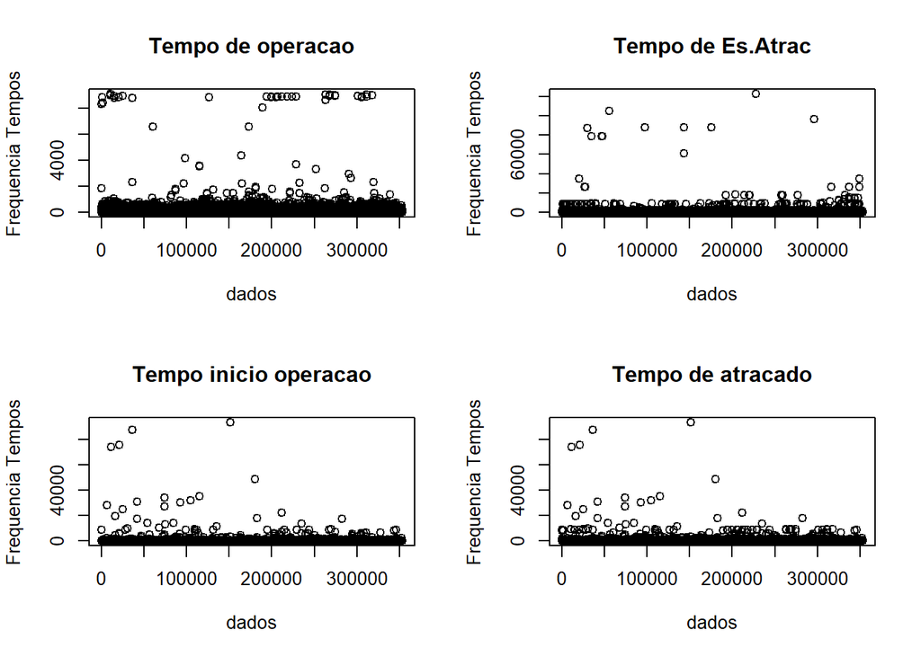

```r
par(mfrow = c(2,2))
plot(dados$TOperacao, main = "Tempo de operacao", xlab = "dados", ylab = "Frequencia Tempos")
plot(dados$TEsperaAtracacao, main = "Tempo de Es.Atrac", xlab = "dados", ylab = "Frequencia Tempos")
plot(dados$TEsperaInicioOp, main = "Tempo inicio operacao", xlab = "dados", ylab = "Frequencia Tempos")
plot(dados$TAtracado, main = "Tempo de atracado", xlab = "dados", ylab = "Frequencia Tempos")
```

Note que graficamente existe valores discrepante em todos os tempos.

A moda é uma medida estatística que mais se repete em um conjunto de dados ela é muito importante principalmente neste contexo. Aqui podemos perceber o quanto um tempo foi anotado diversas vezes na mesma operação.

No r não existe uma função que calcula de imediato a moda, então vamos implementar manualamente a função abaixo retorna a moda.

```r
calc_moda <- function(v) {
  v <- v[!is.na(v)] # Remove NA
  if (length(v) == 0) return(NA_real_)
  uniq_v <- unique(v)
  uniq_v[which.max(tabulate(match(v, uniq_v)))]
}
```

Agora vamos agrupar todos os dados e fazer a análise com bloco de função abaixo, optamos em avaliar a media dos tempos, a mediana que é o valor central que não é influenciada por outliers avaliamos a moda e os limites superior e inferior o que esta dentro destes limites são considerados tempos normais fora deste limete são outliers.

```r
df2 <- dados %>%
  group_by(NRAno, CDTrigrama, CDTUP, TPOperacao) %>%
  summarise(across(
    .cols = c(1:6),
    .fns = list(
      mean = ~ if_else(n() >= 30, mean(.x, na.rm = TRUE), NA_real_),
      mediana = ~ if_else(n() >= 30, median(.x, na.rm = TRUE), NA_real_),
      moda = ~ if_else(n() >= 30, round(calc_moda(.x) * 24 * 60, 2), NA_real_),
      LI = ~ if_else(n() >= 30, quantile(.x, probs = 0.01, na.rm = TRUE), NA_real_),
      LS = ~ if_else(n() >= 30, quantile(.x, probs = 0.99, na.rm = TRUE), NA_real_)
    ),
    .names = "{col}_{fn}"
  ), .groups = 'drop')
```

com as funções acima ja conseguimos calcular toda a descritiva e esta salva no objeto df2 agora retiraremos as linhas que possui NA, mas atenção vamos colocar uma condição se a linha inteira contem NA ai sim retiramos caso contrario deixaremos o valor faltante indicado. Caso fosse realizar procedimentos de modelagem ai sim esses valores teriam outro tratamento como interpolação substituição por médias entre outros tratamento de NA, mas para descritiva podemo deixar em branco.

```r
df3 <- df2 %>%
  filter(if_any(6:34, ~ !is.na(.)))
```

Vamos visualizar agora o cabeçalho dos dados utilizando a função head do R

```r
head(df3)
```

```
## # A tibble: 6 × 34
##   NRAno CDTrigrama CDTUP TPOperacao TEsperaAtracacao_mean TEsperaAtracacao_med…¹
##   <int> <chr>      <chr> <chr>                      <dbl>                  <dbl>
## 1  2019 ""         BRAL… Movimenta…               53.3                   15.5
## 2  2019 ""         BRAM… Movimenta…                0.0167                 0.0167
## 3  2019 ""         BRAM… Movimenta…                0.542                  0.683
## 4  2019 ""         BRAM… Movimenta…               52.8                    0.867
## 5  2019 ""         BRAM… Movimenta…                0.0167                 0.0167
## 6  2019 ""         BRAM… Movimenta…                0.0833                 0.0833
## # ℹ abbreviated name: ¹TEsperaAtracacao_mediana
## # ℹ 28 more variables: TEsperaAtracacao_moda <dbl>, TEsperaAtracacao_LI <dbl>,
## #   TEsperaAtracacao_LS <dbl>, TEsperaInicioOp_mean <dbl>,
## #   TEsperaInicioOp_mediana <dbl>, TEsperaInicioOp_moda <dbl>,
## #   TEsperaInicioOp_LI <dbl>, TEsperaInicioOp_LS <dbl>, TOperacao_mean <dbl>,
## #   TOperacao_mediana <dbl>, TOperacao_moda <dbl>, TOperacao_LI <dbl>,
## #   TOperacao_LS <dbl>, TEsperaDesatracacao_mean <dbl>, …
```

Após a tabela pronta vamos exportar-la o restante desta análise foi feita na ferramenta click sense, por lá percebemos diversos problemas como por exemplo diversos agentes portuários estão marcando o mesmo valor (30 minutos para uma operação as vezes 25) e esta marcação não condiz com a realidade, imagine você em no seu trajeto de trabalho é a mesma distancia que percorre todos os dias nem por isso você gasta exatamente o mesmo tempo para chegada, logo o mesmo raciocínio se aplica aqui. Estes tempos também impacta na avaliação portuária, principalmente no indicador prancha média que não foi avaliado aqui mais esta diretamente ligada com o tempo de operação, esse tempo mede o desmpenho portuário no sentido de sua capacidade de carregamento em toneladas por hora.

Este é um projeto que está em andamento tem muita análise estatística que da pra fazer com estes dados visando melhoria nas atividades portuárias e deixo como trabalho futuro, para quem quiser contribuir vou deixar o arquivo com os dados.

A função abaixo exporta o excel com a análise pronta.

```r
write.xlsx(df3, file = "19-06-2024-outliers-anos-2019-a-2024-movimentacao-carga-e-misto.xlsx")
```